# Fit Initial BG/NBD Models

# 1 Load Datasets

We start by re-loading the data required for these models.

## 1.1 Load Pre-processed Transactional Data

```r
retail_transaction_data_tbl <- read_rds("data/retail_data_cleaned_tbl.rds")
retail_transaction_data_tbl %>% glimpse()
```

```
## Rows: 1,021,424
## Columns: 23
## $ row_id            <chr> "ROW0000001", "ROW0000002", "ROW0000003", "ROW000000…
## $ excel_sheet       <chr> "Year 2009-2010", "Year 2009-2010", "Year 2009-2010"…
## $ invoice_id        <chr> "489434", "489434", "489434", "489434", "489434", "4…
## $ stock_code        <chr> "85048", "79323P", "79323W", "22041", "21232", "2206…
## $ description       <chr> "15CM CHRISTMAS GLASS BALL 20 LIGHTS", "PINK CHERRY …
## $ quantity          <dbl> 12, 12, 12, 48, 24, 24, 24, 10, 12, 12, 24, 12, 10, …
## $ invoice_date      <date> 2009-12-01, 2009-12-01, 2009-12-01, 2009-12-01, 200…
## $ price             <dbl> 6.95, 6.75, 6.75, 2.10, 1.25, 1.65, 1.25, 5.95, 2.55…
## $ customer_id       <chr> "13085", "13085", "13085", "13085", "13085", "13085"…
## $ country           <chr> "United Kingdom", "United Kingdom", "United Kingdom"…
## $ stock_code_upr    <chr> "85048", "79323P", "79323W", "22041", "21232", "2206…
## $ cancellation      <lgl> FALSE, FALSE, FALSE, FALSE, FALSE, FALSE, FALSE, FAL…
## $ invoice_dttm      <dttm> 2009-12-01 07:45:00, 2009-12-01 07:45:00, 2009-12-0…
## $ invoice_month     <chr> "December", "December", "December", "December", "Dec…
## $ invoice_dow       <chr> "Tuesday", "Tuesday", "Tuesday", "Tuesday", "Tuesday…
## $ invoice_dom       <chr> "01", "01", "01", "01", "01", "01", "01", "01", "01"…
## $ invoice_hour      <chr> "07", "07", "07", "07", "07", "07", "07", "07", "07"…
## $ invoice_minute    <chr> "45", "45", "45", "45", "45", "45", "45", "45", "45"…
## $ invoice_woy       <chr> "49", "49", "49", "49", "49", "49", "49", "49", "49"…
## $ invoice_ym        <chr> "200912", "200912", "200912", "200912", "200912", "2…
## $ stock_value       <dbl> 83.40, 81.00, 81.00, 100.80, 30.00, 39.60, 30.00, 59…
## $ invoice_monthprop <dbl> 0.04347826, 0.04347826, 0.04347826, 0.04347826, 0.04…
## $ exclude           <lgl> FALSE, FALSE, FALSE, FALSE, FALSE, FALSE, FALSE, FAL…
```

We also want to load the customer transactional data.

```r
customer_transactions_tbl <- read_rds("data/customer_transactions_tbl.rds")
customer_transactions_tbl %>% glimpse()
```

```
## Rows: 37,031
## Columns: 4
## $ tnx_timestamp <dttm> 2009-12-01 07:45:00, 2009-12-01 07:45:59, 2009-12-01 09…
## $ customer_id   <chr> "13085", "13085", "13078", "15362", "18102", "12682", "1…
## $ invoice_id    <chr> "489434", "489435", "489436", "489437", "489438", "48943…
## $ total_spend   <dbl> 505.30, 145.80, 630.33, 310.75, 2286.24, 426.30, 50.40, …
```

Finally, we want to load the various datasets used to fit the P/NBD models

```r
btyd_fitdata_tbl <- read_rds("data/btyd_fitdata_tbl.rds")

btyd_fitdata_tbl %>% glimpse()
```

```
## Rows: 4,716
## Columns: 6
## $ customer_id    <chr> "12346", "12347", "12348", "12349", "12350", "12351", "…
## $ first_tnx_date <dttm> 2009-12-14 08:34:00, 2010-10-31 14:19:59, 2010-09-27 1…
## $ last_tnx_date  <dttm> 2011-01-18 10:00:59, 2011-01-26 14:29:59, 2011-01-25 1…
## $ x              <dbl> 11, 2, 2, 2, 0, 0, 6, 0, 0, 3, 1, 2, 7, 4, 3, 1, 1, 0, …
## $ t_x            <dbl> 57.151488095, 12.429563492, 17.117361111, 25.970535714,…
## $ T_cal          <dbl> 67.520437, 21.628968, 26.482242, 48.063492, 8.190377, 1…
```

```r
btyd_obs_stats_tbl <- read_rds("data/btyd_obs_stats_tbl.rds")

btyd_obs_stats_tbl %>% glimpse()
```

```
## Rows: 3,849
## Columns: 4
## $ customer_id <chr> "12347", "12348", "12349", "12352", "12353", "12354", "123…
## $ tnx_count   <int> 5, 2, 1, 3, 1, 1, 1, 2, 1, 2, 2, 3, 9, 2, 4, 1, 1, 2, 2, 1…
## $ first_tnx   <dttm> 2011-04-07 10:43:00, 2011-04-05 10:47:00, 2011-11-21 09:5…
## $ last_tnx    <dttm> 2011-12-07 15:51:59, 2011-09-25 13:13:00, 2011-11-21 09:5…
```

```r
extreme_customers_tbl <- read_rds("data/extreme_customers_tbl.rds")

extreme_customers_tbl %>% glimpse()
```

```
## Rows: 1,637
## Columns: 6
## $ customer_id    <chr> "12350", "12351", "12353", "12355", "12357", "12365", "…
## $ first_tnx_date <dttm> 2011-02-02 16:00:59, 2010-11-29 15:23:00, 2010-10-27 1…
## $ last_tnx_date  <dttm> 2011-02-02 16:00:59, 2010-11-29 15:23:00, 2010-10-27 1…
## $ x              <dbl> 0, 0, 0, 0, 1, 1, 0, 0, 0, 0, 0, 0, 0, 0, 0, 0, 0, 0, 0…
## $ t_x            <dbl> 0.000000000, 0.000000000, 0.000000000, 0.000000000, 0.0…
## $ T_cal          <dbl> 8.190377, 17.479861, 22.209921, 44.928671, 19.368552, 5…
```

## 1.2 Construct Customer Cohorts

Later in this worksheet we will want to create customer cohorts based on the date of the first transaction for each customer.

```r
customer_cohortdata_tbl <- customer_transactions_tbl %>%
  group_by(customer_id) %>%
  summarise(
    .groups = "drop",

    first_tnx_date = min(tnx_timestamp)
    ) %>%
  mutate(
    cohort_qtr = first_tnx_date %>% as.yearqtr(),
    cohort_ym  = first_tnx_date %>% format("%Y %m"),

    .after = "customer_id"
    )

customer_cohortdata_tbl %>% glimpse()
```

```
## Rows: 5,878
## Columns: 4
## $ customer_id    <chr> "12346", "12347", "12348", "12349", "12350", "12351", "…
## $ cohort_qtr     <yearqtr> 2009 Q4, 2010 Q4, 2010 Q3, 2010 Q2, 2011 Q1, 2010 Q…
## $ cohort_ym      <chr> "2009 12", "2010 10", "2010 09", "2010 04", "2011 02", …
## $ first_tnx_date <dttm> 2009-12-14 08:34:00, 2010-10-31 14:19:59, 2010-09-27 1…
```

# 2 Fit Initial BG/NBD Model

```r
stan_modeldir <- "stan_models"
stan_codedir  <-   "stan_code"
```

```
## functions {
##   #include util_functions.stan
## }
##
## data {
##   int<lower=1> n;           // number of customers
##
##   vector<lower=0>[n] t_x;   // time to most recent purchase
##   vector<lower=0>[n] T_cal; // total observation time
##   vector<lower=0>[n] x;     // number of purchases observed
##
##   real<lower=0> lambda_mn;  // prior mean for lambda
##   real<lower=0> lambda_cv;  // prior cv   for lambda
##
##   real<lower=0,upper=1> p_mn; // prior mean     for p
##   real<lower=0>         p_k;  // prior strength for p
## }
##
##
## transformed data {
##   real<lower=0> r     = 1 / (lambda_cv * lambda_cv);
##   real<lower=0> alpha = 1 / (lambda_cv * lambda_cv * lambda_mn);
##
##   real<lower=0> a     = p_k * p_mn;
##   real<lower=0> b     = p_k * (1 - p_mn);
## }
##
##
## parameters {
##   vector<lower=0>[n]         lambda;  // purchase rate
##   vector<lower=0,upper=1>[n] p;       // dropout probabilit
## }
##
##
## model {
##   // setting priors
##   lambda ~ gamma(r, alpha);
##   p      ~ beta (a, b);
##
##   target += calculate_bgnbd_loglik(n, lambda, p, x, t_x, T_cal);
## }
```

We now compile this model using `CmdStanR`.

```r
bgnbd_fixed_stanmodel <- cmdstan_model(
  "stan_code/bgnbd_fixed.stan",
  include_paths =   stan_codedir,
  pedantic      =           TRUE,
  dir           =  stan_modeldir
  )
```

## 2.1 Fit the Model

We then use this compiled model with our data to produce a fit of the data.

```r
stan_modelname <- "bgnbd_fixed"
stanfit_prefix <- str_c("fit_", stan_modelname)

stan_data_lst <- btyd_fitdata_tbl %>%
  select(customer_id, x, t_x, T_cal) %>%
  compose_data(
    lambda_mn = 0.25,
    lambda_cv = 1.00,

    p_mn      =  0.10,
    p_k       =  2.00,
    )

bgnbd_fixed_stanfit <- bgnbd_fixed_stanmodel$sample(
  data            =                stan_data_lst,
  chains          =                            4,
  iter_warmup     =                          500,
  iter_sampling   =                          500,
  seed            =                         4201,
  save_warmup     =                         TRUE,
  output_dir      =                stan_modeldir,
  output_basename =               stanfit_prefix,
  )
```

[output not shown]

```r
bgnbd_fixed_stanfit$summary()
```

```
## # A tibble: 9,433 × 10
##    variable        mean   median      sd     mad       q5      q95  rhat ess_b…¹
##    <chr>          <dbl>    <dbl>   <dbl>   <dbl>    <dbl>    <dbl> <dbl>   <dbl>
##  1 lp__        -7.02e+4 -7.02e+4 84.8    85.2    -7.04e+4 -7.01e+4  1.00    536.
##  2 lambda[1]    1.70e-1  1.64e-1  0.0486  0.0469  1.00e-1  2.59e-1  1.00   2106.
##  3 lambda[2]    1.32e-1  1.15e-1  0.0811  0.0699  3.15e-2  2.90e-1  1.00   1568.
##  4 lambda[3]    1.06e-1  9.32e-2  0.0635  0.0592  2.83e-2  2.21e-1  1.00   2168.
##  5 lambda[4]    7.04e-2  5.97e-2  0.0473  0.0383  1.68e-2  1.65e-1  1.00   1484.
##  6 lambda[5]    1.56e-1  8.45e-2  0.198   0.0963  4.12e-3  5.71e-1  1.00   1322.
##  7 lambda[6]    1.60e-1  7.31e-2  0.220   0.0868  4.60e-3  6.20e-1  1.00   1143.
##  8 lambda[7]    2.95e-1  2.84e-1  0.110   0.108   1.35e-1  4.96e-1  1.00   2095.
##  9 lambda[8]    1.66e-1  7.06e-2  0.229   0.0887  4.03e-3  6.04e-1  1.00   1001.
## 10 lambda[9]    1.93e-1  9.87e-2  0.244   0.129   3.01e-3  6.95e-1  1.00    914.
## # … with 9,423 more rows, 1 more variable: ess_tail <dbl>, and abbreviated
## #   variable name ¹ess_bulk
```

We have some basic HMC-based validity statistics we can check.

```r
bgnbd_fixed_stanfit$cmdstan_diagnose()
```

```
## Processing csv files: /home/rstudio/workshop/stan_models/fit_bgnbd_fixed-1.csvWarning: non-fatal error reading adaptation data
## , /home/rstudio/workshop/stan_models/fit_bgnbd_fixed-2.csvWarning: non-fatal error reading adaptation data
## , /home/rstudio/workshop/stan_models/fit_bgnbd_fixed-3.csvWarning: non-fatal error reading adaptation data
## , /home/rstudio/workshop/stan_models/fit_bgnbd_fixed-4.csvWarning: non-fatal error reading adaptation data
##
##
## Checking sampler transitions treedepth.
## Treedepth satisfactory for all transitions.
##
## Checking sampler transitions for divergences.
## No divergent transitions found.
##
## Checking E-BFMI - sampler transitions HMC potential energy.
## E-BFMI satisfactory.
##
## Effective sample size satisfactory.
##
## Split R-hat values satisfactory all parameters.
##
## Processing complete, no problems detected.
```

## 2.2 Visual Diagnostics of the Sample Validity

Now that we have a sample from the posterior distribution we need to create a few different visualisations of the diagnostics.

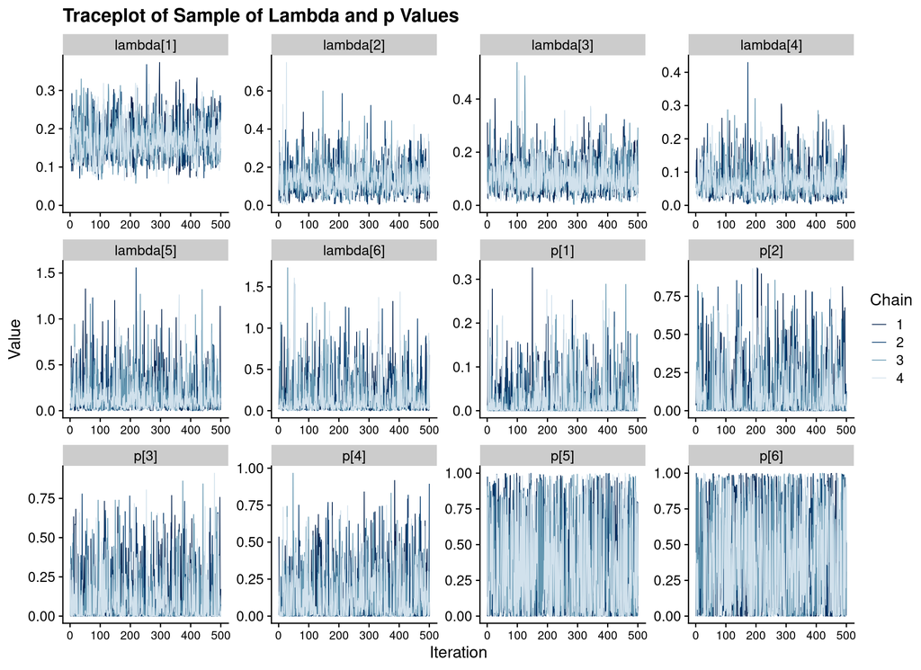

```r
sample_params <- c(
  "lambda[1]", "lambda[2]", "lambda[3]", "lambda[4]", "lambda[5]", "lambda[6]",
  "p[1]",      "p[2]",      "p[3]",      "p[4]",      "p[5]",      "p[6]"
  )

bgnbd_fixed_stanfit$draws(inc_warmup = FALSE) %>%
  mcmc_trace(pars = sample_params) +
  expand_limits(y = 0) +
  labs(
    x = "Iteration",
    y = "Value",
    title = "Traceplot of Sample of Lambda and p Values"
    ) +
  theme(axis.text.x = element_text(size = 10))
```

A common MCMC diagnostic is $\hat{R}$ - which is a measure of the ‘similarity’ of the chains.

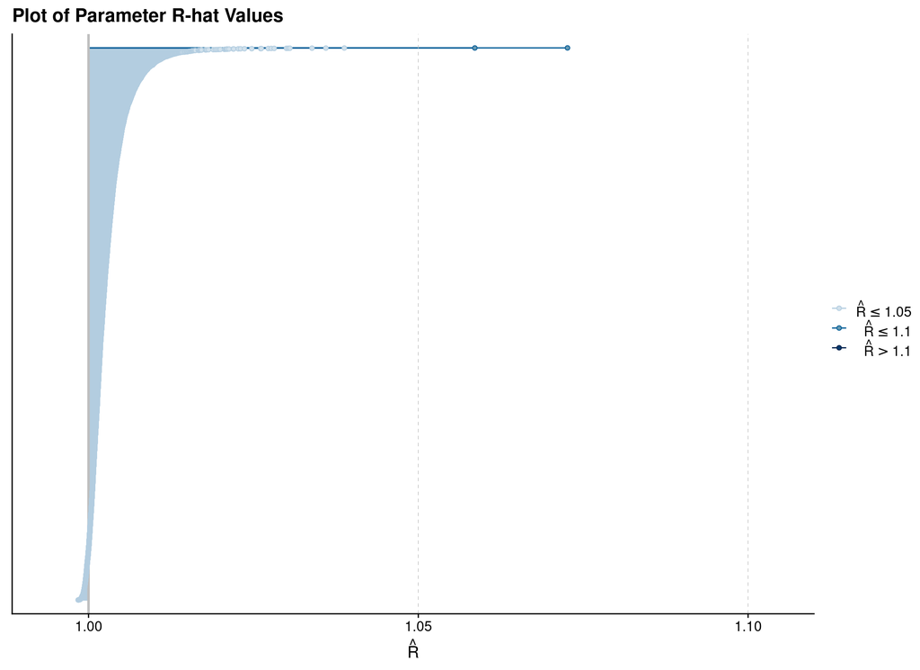

```r
bgnbd_fixed_stanfit %>%
  rhat(pars = c("lambda", "p")) %>%
  mcmc_rhat() +
    ggtitle("Plot of Parameter R-hat Values")
```

Related to this quantity is the concept of *effective sample size*, $N_{eff}$, an estimate of the size of the sample from a statistical information point of view.

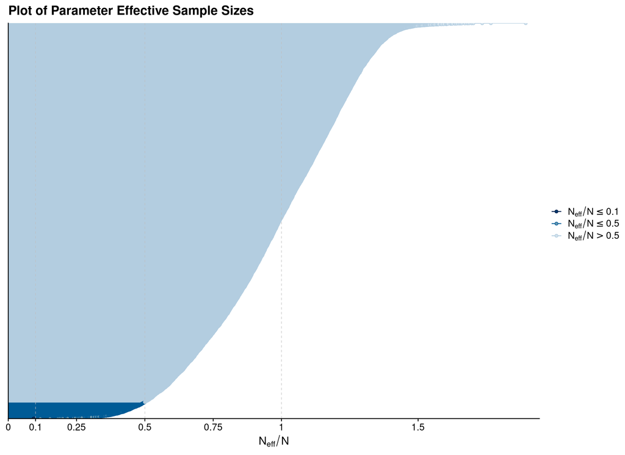

```r
bgnbd_fixed_stanfit %>%
  neff_ratio(pars = c("lambda", "p")) %>%
  mcmc_neff() +
    ggtitle("Plot of Parameter Effective Sample Sizes")
```

Finally, we also want to look at autocorrelation in the chains for each parameter.

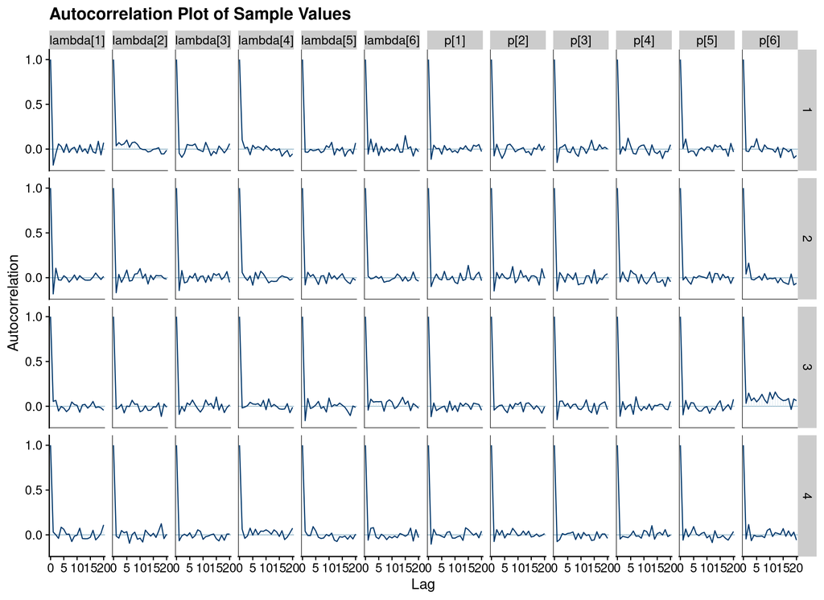

```r
bgnbd_fixed_stanfit$draws() %>%
  mcmc_acf(pars = sample_params) +
    ggtitle("Autocorrelation Plot of Sample Values")
```

We now want to validate the outputs of this model by looking at the posteriors for both $\lambda$, $\mu$ and `p_alive`, and then running our simulations using these outputs.

```r
bgnbd_fixed_validation_tbl <- bgnbd_fixed_stanfit %>%
  recover_types(btyd_fitdata_tbl) %>%
  spread_draws(lambda[customer_id], p[customer_id]) %>%
  ungroup() %>%
  select(
    customer_id, draw_id = .draw, post_lambda = lambda, post_p = p
    )

bgnbd_fixed_validation_tbl %>% glimpse()
```

```
## Rows: 9,432,000
## Columns: 4
## $ customer_id <chr> "12346", "12346", "12346", "12346", "12346", "12346", "123…
## $ draw_id     <int> 1, 2, 3, 4, 5, 6, 7, 8, 9, 10, 11, 12, 13, 14, 15, 16, 17,…
## $ post_lambda <dbl> 0.180236, 0.172071, 0.141616, 0.217568, 0.140565, 0.189864…
## $ post_p      <dbl> 1.19683e-02, 3.29180e-02, 1.84563e-01, 2.63856e-05, 1.4862…
```

Having constructed our simulations inputs, we now generate our simulations.

```r
precompute_dir <- "precompute/bgnbd_fixed"

precomputed_tbl <- dir_ls(precompute_dir) %>%
  enframe(name = NULL, value = "sim_file") %>%
  mutate(sim_file = sim_file %>% as.character())


bgnbd_fixed_validsims_lookup_tbl <- bgnbd_fixed_validation_tbl %>%
  group_nest(customer_id, .key = "cust_params") %>%
  mutate(
    sim_file = glue(
      "{precompute_dir}/sims_bgnbd_fixed_{customer_id}.rds"
      )
    )


exec_tbl <-  bgnbd_fixed_validsims_lookup_tbl %>%
  anti_join(precomputed_tbl, by = "sim_file")


if(exec_tbl %>% nrow() > 0) {
  exec_tbl %>%
    mutate(
      calc_file = future_map2_lgl(
        sim_file, cust_params,
        run_bgnbd_simulations_chunk,
        start_dttm = as.POSIXct("2011-04-01"),
        end_dttm   = as.POSIXct("2011-12-10"),

        .options = furrr_options(
          globals  = c(
            "calculate_event_times", "rgamma_mucv", "gamma_mucv2shaperate",
            "generate_bgnbd_validation_transactions"
            ),
          packages   = c("tidyverse", "fs"),
          scheduling = FALSE,
          seed       = 4202
          ),
        .progress = TRUE
        )
      )
}

exec_tbl %>% glimpse()
```

```
## Rows: 0
## Columns: 3
## $ customer_id <chr>
## $ cust_params <list<tibble[,3]>> list()
## $ sim_file    <glue>
```

```r
bgnbd_fixed_validsims_lookup_tbl %>% glimpse()
```

```
## Rows: 4,716
## Columns: 3
## $ customer_id <chr> "12346", "12347", "12348", "12349", "12350", "12351", "123…
## $ cust_params <list<tibble[,3]>> [<tbl_df[2000 x 3]>], [<tbl_df[2000 x 3]>], […
## $ sim_file    <glue> "precompute/bgnbd_fixed/sims_bgnbd_fixed_12346.rds", "pre…
```

We now load all the simulations into a file.

```r
bgnbd_fixed_validsims_tbl <- bgnbd_fixed_validsims_lookup_tbl %>%
  mutate(
    data = map(sim_file, ~ .x %>% read_rds() %>% select(draw_id, sim_tnx_count, sim_tnx_last))
    ) %>%
  select(customer_id, sim_file, data) %>%
  unnest(data)

bgnbd_fixed_validsims_tbl %>% glimpse()
```

```
## Rows: 9,432,000
## Columns: 5
## $ customer_id   <chr> "12346", "12346", "12346", "12346", "12346", "12346", "12346", "12346", "12346", "12346", "12346", "12346", "12346", "12346", "12346", "12346", "1…
## $ sim_file      <glue> "precompute/bgnbd_fixed/sims_bgnbd_fixed_12346.rds", "precompute/bgnbd_fixed/sims_bgnbd_fixed_12346.rds", "precompute/bgnbd_fixed/sims_bgnbd_fixe…
## $ draw_id       <int> 1, 2, 3, 4, 5, 6, 7, 8, 9, 10, 11, 12, 13, 14, 15, 16, 17, 18, 19, 20, 21, 22, 23, 24, 25, 26, 27, 28, 29, 30, 31, 32, 33, 34, 35, 36, 37, 38, 39,…
## $ sim_tnx_count <int> 4, 6, 2, 12, 5, 9, 6, 10, 3, 1, 5, 5, 2, 4, 7, 8, 3, 5, 4, 14, 10, 10, 5, 5, 0, 5, 7, 3, 3, 8, 5, 6, 7, 6, 4, 6, 5, 4, 0, 5, 7, 5, 0, 3, 1, 7, 2, …
## $ sim_tnx_last  <dttm> 2011-06-20 17:23:02, 2011-11-18 00:06:53, 2011-06-11 16:36:53, 2011-11-07 20:42:55, 2011-09-01 02:03:26, 2011-10-15 00:57:51, 2011-12-04 04:47:00…
```

We also want to look at how our simulated data compares to the transaction data that occurred after Apr 1 2011.

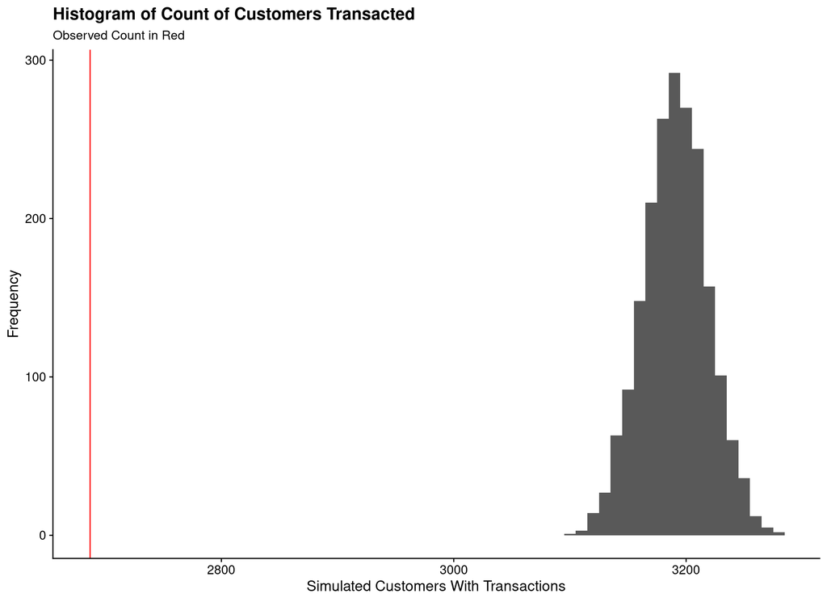

```r
tnx_data_tbl <- btyd_obs_stats_tbl %>%
  semi_join(bgnbd_fixed_validsims_tbl, by = "customer_id")

obs_customer_count  <- tnx_data_tbl %>% nrow()
obs_total_tnx_count <- tnx_data_tbl %>% pull(tnx_count) %>% sum()

bgnbd_fixed_tnx_simsumm_tbl <- bgnbd_fixed_validsims_tbl %>%
  group_by(draw_id) %>%
  summarise(
    .groups = "drop",

    sim_customer_count  = length(sim_tnx_count[sim_tnx_count > 0]),
    sim_total_tnx_count = sum(sim_tnx_count)
    )


ggplot(bgnbd_fixed_tnx_simsumm_tbl) +
  geom_histogram(aes(x = sim_customer_count), binwidth = 10) +
  geom_vline(aes(xintercept = obs_customer_count), colour = "red") +
  labs(
    x = "Simulated Customers With Transactions",
    y = "Frequency",
    title = "Histogram of Count of Customers Transacted",
    subtitle = "Observed Count in Red"
    )
```

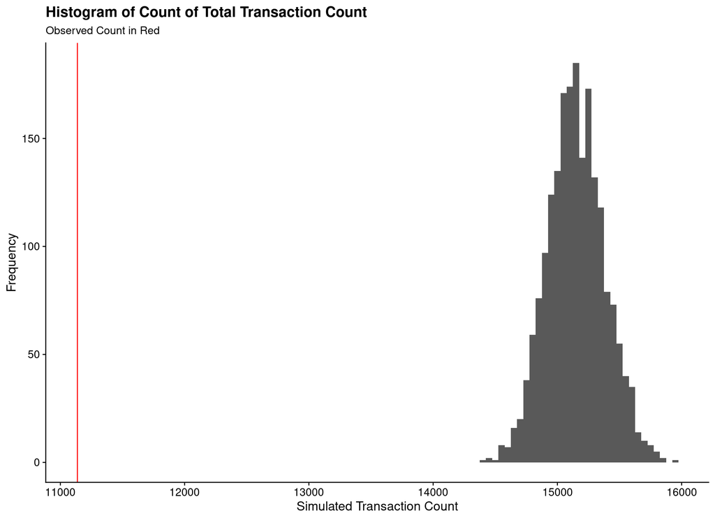

```r
ggplot(bgnbd_fixed_tnx_simsumm_tbl) +
  geom_histogram(aes(x = sim_total_tnx_count), binwidth = 50) +
  geom_vline(aes(xintercept = obs_total_tnx_count), colour = "red") +
  labs(
    x = "Simulated Transaction Count",
    y = "Frequency",
    title = "Histogram of Count of Total Transaction Count",
    subtitle = "Observed Count in Red"
    )
```

So we have gone from a strong under-estimation bias to a strong over-estimation bias, but the model is fitting much faster, so working on this.

# 3 Fit Hierarchical Mean BG/NBD Model

```
## functions {
##   #include util_functions.stan
## }
##
## data {
##   int<lower=1> n;           // number of customers
##
##   vector<lower=0>[n] t_x;   // time to most recent purchase
##   vector<lower=0>[n] T_cal; // total observation time
##   vector<lower=0>[n] x;     // number of purchases observed
##
##   real          lambda_mn_p1;  // lambda mean prior p1
##   real<lower=0> lambda_mn_p2;  // lambda mean prior p2
##
##   real<lower=0> lambda_cv;
##
##   real<lower=0> p_mn_mu;       // p mean prior p1
##   real<lower=0> p_mn_k;        // p mean prior p2
##
##   real<lower=0> p_k;
## }
##
##
## transformed data {
##   real<lower=0> r = 1 / (lambda_cv * lambda_cv);
##
##   real<lower=0> p_mn_a = p_mn_k * p_mn_mu;
##   real<lower=0> p_mn_b = p_mn_k * (1 - p_mn_mu);
## }
##
## parameters {
##   real<lower=0>              lambda_mn;
##   real<lower=0,upper=1>      p_mn;
##
##   vector<lower=0>[n]         lambda;  // purchase rate
##   vector<lower=0,upper=1>[n] p;       // dropout probabilit
## }
##
##
## transformed parameters {
##   real<lower=0> alpha = 1 / (lambda_cv * lambda_cv * lambda_mn);
##
##   real<lower=0> p_a   = p_k * p_mn;
##   real<lower=0> p_b   = p_k * (1 - p_mn);
## }
##
##
## model {
##   // set hyper-priors
##   lambda_mn ~ lognormal(lambda_mn_p1, lambda_mn_p2);
##
##   p_mn      ~ beta     (p_mn_a, p_mn_b);
##
##   // setting priors
##   lambda ~ gamma(r,   alpha);
##   p      ~ beta (p_a, p_b);
##
##   target += calculate_bgnbd_loglik(n, lambda, p, x, t_x, T_cal);
## }
```

We now compile this model using `CmdStanR`.

```r
bgnbd_hier_means_stanmodel <- cmdstan_model(
  "stan_code/bgnbd_hier_means.stan",
  include_paths =   stan_codedir,
  pedantic      =           TRUE,
  dir           =  stan_modeldir
)
```

## 3.1 Fit the Model

We then use this compiled model with our data to produce a fit of the data.

```r
stan_modelname <- "bgnbd_hier_means"
stanfit_prefix <- str_c("fit_", stan_modelname)

stan_data_lst <- btyd_fitdata_tbl %>%
  select(customer_id, x, t_x, T_cal) %>%
  compose_data(
    lambda_mn_p1 = log(1) - 0.5 * (1.0)^2,
    lambda_mn_p2 = 1.0,

    lambda_cv    = 1.0,

    p_mn_mu      = 0.1,
    p_mn_k       = 10,

    p_k          = 10
  )

bgnbd_hier_means_stanfit <- bgnbd_hier_means_stanmodel$sample(
  data            =                stan_data_lst,
  chains          =                            4,
  iter_warmup     =                          500,
  iter_sampling   =                          500,
  seed            =                         4202,
  save_warmup     =                         TRUE,
  output_dir      =                stan_modeldir,
  output_basename =               stanfit_prefix,
)
```

[output not shown]

```r
bgnbd_hier_means_stanfit$summary()
```

```
## # A tibble: 9,438 × 10
##    variable         mean      median        sd      mad           q5        q95  rhat ess_bulk ess_tail
##    <chr>           <dbl>       <dbl>     <dbl>    <dbl>        <dbl>      <dbl> <dbl>    <dbl>    <dbl>
##  1 lp__      -64067.     -64065.     103.      99.9     -64244.      -63903.    1.02     131.      434.
##  2 lambda_mn      0.121       0.121    0.00257  0.00261      0.117        0.126 1.01     567.     1199.
##  3 p_mn           0.170       0.170    0.00555  0.00557      0.161        0.179 1.04      97.7     307.
##  4 lambda[1]      0.166       0.161    0.0486   0.0475       0.0964       0.252 0.999   2807.     1226.
##  5 lambda[2]      0.116       0.102    0.0701   0.0613       0.0301       0.247 1.00    1821.      844.
##  6 lambda[3]      0.0946      0.0852   0.0550   0.0515       0.0259       0.202 1.00    2220.     1313.
##  7 lambda[4]      0.0682      0.0582   0.0449   0.0362       0.0166       0.149 1.00    3056.     1117.
##  8 lambda[5]      0.0803      0.0516   0.0897   0.0553       0.00329      0.253 1.00    2252.     1109.
##  9 lambda[6]      0.0737      0.0409   0.0943   0.0450       0.00286      0.269 1.00    2399.     1136.
## 10 lambda[7]      0.250       0.237    0.0986   0.0921       0.112        0.436 1.00    3406.     1596.
## # … with 9,428 more rows
```

We have some basic HMC-based validity statistics we can check.

```r
bgnbd_hier_means_stanfit$cmdstan_diagnose()
```

```
## Processing csv files: /home/rstudio/workshop/stan_models/fit_bgnbd_hier_means-1.csvWarning: non-fatal error reading adaptation data
## , /home/rstudio/workshop/stan_models/fit_bgnbd_hier_means-2.csvWarning: non-fatal error reading adaptation data
## , /home/rstudio/workshop/stan_models/fit_bgnbd_hier_means-3.csvWarning: non-fatal error reading adaptation data
## , /home/rstudio/workshop/stan_models/fit_bgnbd_hier_means-4.csvWarning: non-fatal error reading adaptation data
##
##
## Checking sampler transitions treedepth.
## Treedepth satisfactory for all transitions.
##
## Checking sampler transitions for divergences.
## No divergent transitions found.
##
## Checking E-BFMI - sampler transitions HMC potential energy.
## E-BFMI satisfactory.
##
## Effective sample size satisfactory.
##
## Split R-hat values satisfactory all parameters.
##
## Processing complete, no problems detected.
```

## 3.2 Visual Diagnostics of the Sample Validity

Now that we have a sample from the posterior distribution we need to create a few different visualisations of the diagnostics.

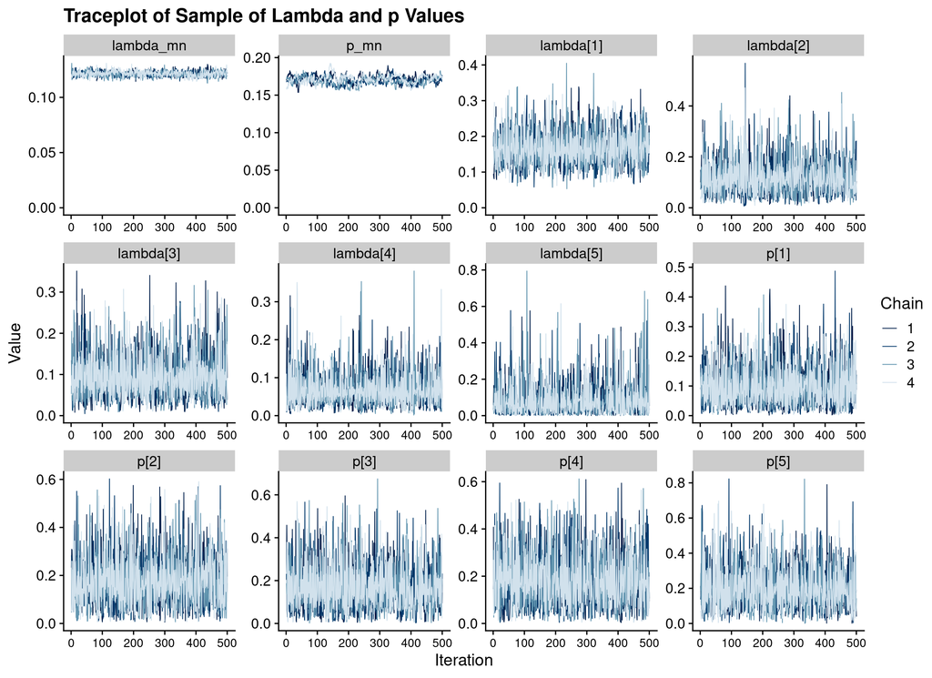

```r
sample_params <- c(
  "lambda_mn", "p_mn",
  "lambda[1]", "lambda[2]", "lambda[3]", "lambda[4]", "lambda[5]",
  "p[1]",      "p[2]",      "p[3]",      "p[4]",      "p[5]"
  )

bgnbd_hier_means_stanfit$draws(inc_warmup = FALSE) %>%
  mcmc_trace(pars = sample_params) +
  expand_limits(y = 0) +
  labs(
    x = "Iteration",
    y = "Value",
    title = "Traceplot of Sample of Lambda and p Values"
    ) +
  theme(axis.text.x = element_text(size = 10))
```

A common MCMC diagnostic is $\hat{R}$ - which is a measure of the ‘similarity’ of the chains.

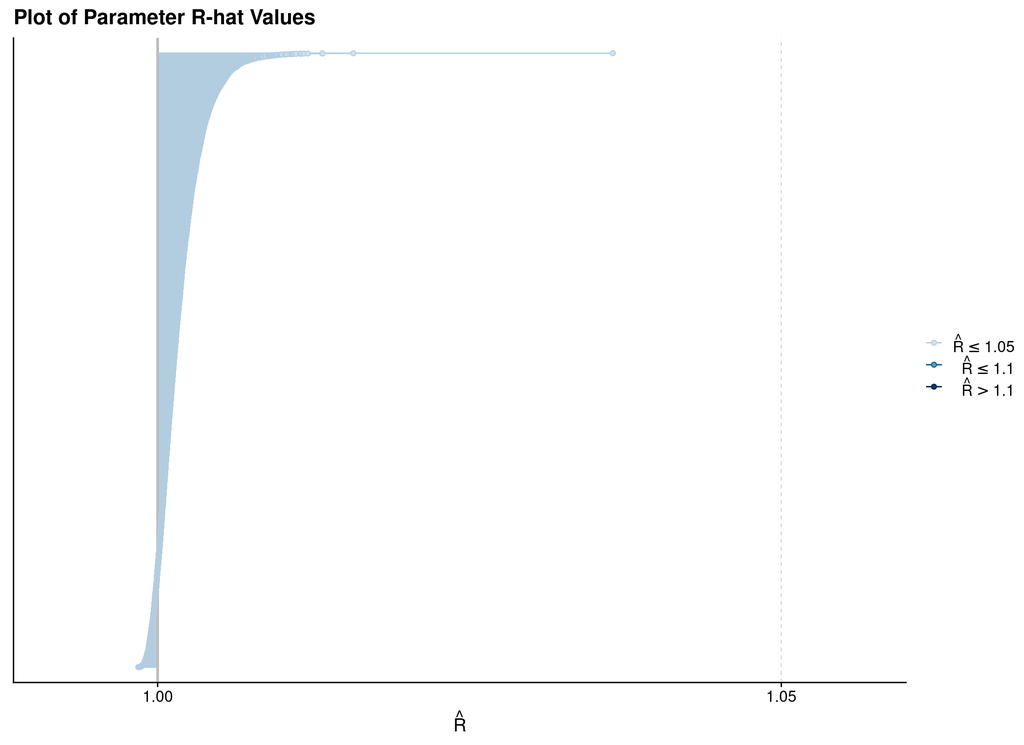

```r
bgnbd_hier_means_stanfit %>%
  rhat(pars = c("lambda_mn", "p_mn", "lambda", "p")) %>%
  mcmc_rhat() +
    ggtitle("Plot of Parameter R-hat Values")
```

Related to this quantity is the concept of *effective sample size*, $N_{eff}$, an estimate of the size of the sample from a statistical information point of view.

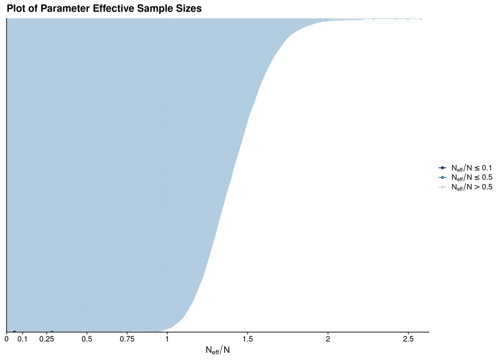

```r
bgnbd_hier_means_stanfit %>%
  neff_ratio(pars = c("lambda_mn", "p_mn", "lambda", "p")) %>%
  mcmc_neff() +
    ggtitle("Plot of Parameter Effective Sample Sizes")
```

## 3.3 Validate the Hierarchical Lambda-Mean Model

We now want to validate the outputs of this model by looking at the posteriors for both $\lambda$, $\mu$ and `p_alive`, and then running our simulations using these outputs.

```r
bgnbd_hier_means_validation_tbl <- bgnbd_hier_means_stanfit %>%
  recover_types(btyd_fitdata_tbl) %>%
  spread_draws(lambda[customer_id], p[customer_id]) %>%
  ungroup() %>%
  select(
    customer_id, draw_id = .draw, post_lambda = lambda, post_p = p
    )

bgnbd_hier_means_validation_tbl %>% glimpse()
```

```
## Rows: 9,432,000
## Columns: 4
## $ customer_id <chr> "12346", "12346", "12346", "12346", "12346", "12346", "123…
## $ draw_id     <int> 1, 2, 3, 4, 5, 6, 7, 8, 9, 10, 11, 12, 13, 14, 15, 16, 17,…
## $ post_lambda <dbl> 0.0953844, 0.0853009, 0.0811996, 0.2378080, 0.1220780, 0.2…
## $ post_p      <dbl> 0.0948068, 0.0799318, 0.1330810, 0.1203820, 0.0702531, 0.0…
```

Having constructed our simulations inputs, we now generate our simulations.

```r
precompute_dir <- "precompute/bgnbd_hier_means"

precomputed_tbl <- dir_ls(precompute_dir) %>%
  enframe(name = NULL, value = "sim_file") %>%
  mutate(sim_file = sim_file %>% as.character())


bgnbd_hier_means_validsims_lookup_tbl <- bgnbd_hier_means_validation_tbl %>%
  group_nest(customer_id, .key = "cust_params") %>%
  mutate(
    sim_file = glue(
      "{precompute_dir}/sims_bgnbd_hier_means_{customer_id}.rds"
      )
    )


exec_tbl <-  bgnbd_hier_means_validsims_lookup_tbl %>%
  anti_join(precomputed_tbl, by = "sim_file")


if(exec_tbl %>% nrow() > 0) {
  exec_tbl %>%
    mutate(
      calc_file = future_map2_lgl(
        sim_file, cust_params,
        run_bgnbd_simulations_chunk,
        start_dttm = as.POSIXct("2011-04-01"),
        end_dttm   = as.POSIXct("2011-12-10"),

        .options = furrr_options(
          globals  = c(
            "calculate_event_times", "rgamma_mucv", "gamma_mucv2shaperate",
            "generate_bgnbd_validation_transactions"
            ),
          packages   = c("tidyverse", "fs"),
          scheduling = FALSE,
          seed       = 4202
          ),
        .progress = TRUE
        )
      )
}
```

```
## # A tibble: 870 × 4
##    customer_id        cust_params sim_file                               calc_…¹
##    <chr>       <list<tibble[,3]>> <glue>                                 <lgl>
##  1 17202              [2,000 × 3] precompute/bgnbd_hier_means/sims_bgnb… TRUE
##  2 17203              [2,000 × 3] precompute/bgnbd_hier_means/sims_bgnb… TRUE
##  3 17204              [2,000 × 3] precompute/bgnbd_hier_means/sims_bgnb… TRUE
##  4 17205              [2,000 × 3] precompute/bgnbd_hier_means/sims_bgnb… TRUE
##  5 17207              [2,000 × 3] precompute/bgnbd_hier_means/sims_bgnb… TRUE
##  6 17208              [2,000 × 3] precompute/bgnbd_hier_means/sims_bgnb… TRUE
##  7 17209              [2,000 × 3] precompute/bgnbd_hier_means/sims_bgnb… TRUE
##  8 17210              [2,000 × 3] precompute/bgnbd_hier_means/sims_bgnb… TRUE
##  9 17211              [2,000 × 3] precompute/bgnbd_hier_means/sims_bgnb… TRUE
## 10 17212              [2,000 × 3] precompute/bgnbd_hier_means/sims_bgnb… TRUE
## # … with 860 more rows, and abbreviated variable name ¹calc_file
```

```r
exec_tbl %>% glimpse()
```

```
## Rows: 870
## Columns: 3
## $ customer_id <chr> "17202", "17203", "17204", "17205", "17207", "17208", "172…
## $ cust_params <list<tibble[,3]>> [<tbl_df[2000 x 3]>], [<tbl_df[2000 x 3]>], […
## $ sim_file    <glue> "precompute/bgnbd_hier_means/sims_bgnbd_hier_means_17202.…
```

```r
bgnbd_hier_means_validsims_lookup_tbl %>% glimpse()
```

```
## Rows: 4,716
## Columns: 3
## $ customer_id <chr> "12346", "12347", "12348", "12349", "12350", "12351", "123…
## $ cust_params <list<tibble[,3]>> [<tbl_df[2000 x 3]>], [<tbl_df[2000 x 3]>], […
## $ sim_file    <glue> "precompute/bgnbd_hier_means/sims_bgnbd_hier_means_12346.…
```

We now load all the simulations into a file.

```r
bgnbd_hier_means_validsims_tbl <- bgnbd_hier_means_validsims_lookup_tbl %>%
  mutate(
    data = map(sim_file, ~ .x %>% read_rds() %>% select(draw_id, sim_tnx_count, sim_tnx_last))
    ) %>%
  select(customer_id, sim_file, data) %>%
  unnest(data)

bgnbd_hier_means_validsims_tbl %>% glimpse()
```

```
## Rows: 9,432,000
## Columns: 5
## $ customer_id   <chr> "12346", "12346", "12346", "12346", "12346", "12346", "1…
## $ sim_file      <glue> "precompute/bgnbd_hier_means/sims_bgnbd_hier_means_1234…
## $ draw_id       <int> 1, 2, 3, 4, 5, 6, 7, 8, 9, 10, 11, 12, 13, 14, 15, 16, 1…
## $ sim_tnx_count <int> 4, 3, 1, 3, 1, 2, 1, 3, 9, 1, 2, 12, 0, 7, 9, 3, 7, 6, 3…
## $ sim_tnx_last  <dttm> 2011-08-31 12:49:57, 2011-11-09 15:56:17, 2011-05-19 05…
```

We also want to look at how our simulated data compares to the transaction data that occurred after Apr 1 2011.

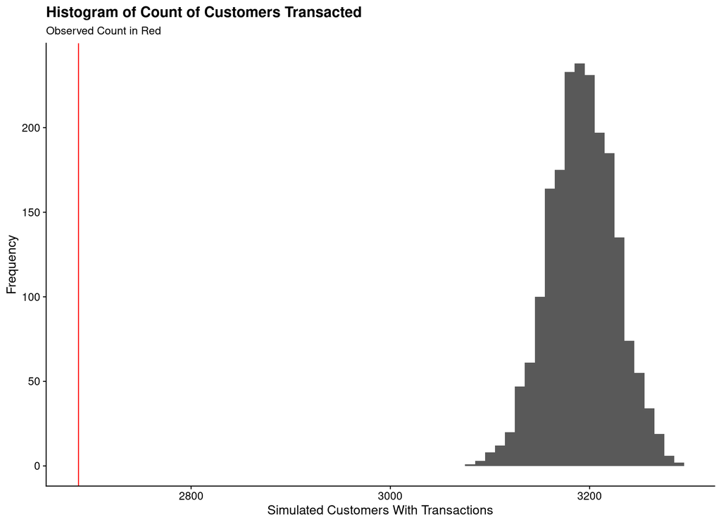

```r
tnx_data_tbl <- btyd_obs_stats_tbl %>%
  semi_join(bgnbd_hier_means_validsims_tbl, by = "customer_id")

obs_customer_count  <- tnx_data_tbl %>% nrow()
obs_total_tnx_count <- tnx_data_tbl %>% pull(tnx_count) %>% sum()

bgnbd_hier_means_tnx_simsumm_tbl <- bgnbd_hier_means_validsims_tbl %>%
  group_by(draw_id) %>%
  summarise(
    .groups = "drop",

    sim_customer_count  = length(sim_tnx_count[sim_tnx_count > 0]),
    sim_total_tnx_count = sum(sim_tnx_count)
    )


ggplot(bgnbd_hier_means_tnx_simsumm_tbl) +
  geom_histogram(aes(x = sim_customer_count), binwidth = 10) +
  geom_vline(aes(xintercept = obs_customer_count), colour = "red") +
  labs(
    x = "Simulated Customers With Transactions",
    y = "Frequency",
    title = "Histogram of Count of Customers Transacted",
    subtitle = "Observed Count in Red"
    )
```

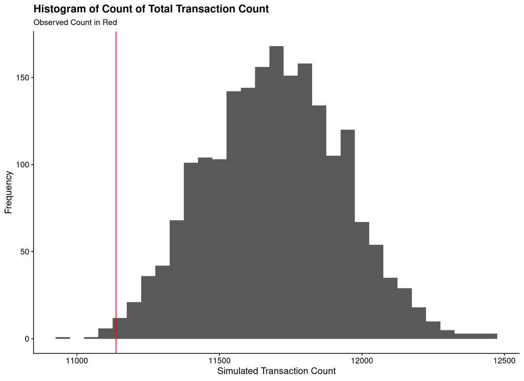

```r
ggplot(bgnbd_hier_means_tnx_simsumm_tbl) +
  geom_histogram(aes(x = sim_total_tnx_count), binwidth = 50) +
  geom_vline(aes(xintercept = obs_total_tnx_count), colour = "red") +
  labs(
    x = "Simulated Transaction Count",
    y = "Frequency",
    title = "Histogram of Count of Total Transaction Count",
    subtitle = "Observed Count in Red"
    )
```

# 4 R Environment

```r
options(width = 120L)
```

```r
options(width = 80L)
```